# **K Means Clustering with Python**

Estimated time needed: **45** minutes

How do brands always know which new products should recommend to me? Can they read my mind? Well, sort of. By (legally) gathering information about you and your purchasing habits, corporations are able to group you with other customers that have similar characteristics. K Means clustering is one such algorithm that can categorize similar people! Then, companies can determine this population's potential preferences and personalize your experience with the brand, which ranges from product recommendations to email marketing content.

In this notebook, you will learn the fundamentals of how to accomplish grouping with K Means and use it for segmenting mall customers and images.

[figure not shown]

1. Objectives
2. Setup
   1. Installing Required Libraries
   2. Importing Required Libraries
3. Introduction
   1. How does K Means Clustering work?
4. Example 1: Visual Intuition
5. Example 2: Segmenting Customer Data
   1. Problem Statement
   2. About the Dataset
   3. Loading the Dataset
   4. Getting familiar with the data
   5. Clustering the data using K Means
6. Example 3: Image Segmentation
   1. Loading the Data
   2. Segmenting the image using 2 clusters
   3. Converting to black and white

Exercises

1. Exercise 1 - Fitting K Means with k=2
2. Exercise 2 - Viewing Segmented Image
3. Exercise 3 - Fitting K Means with k=4 and Viewing Segmented Image

## 1: Visual intuition

Take a look at the following animation for some physical intuition of what's going on during each iteration.

[figure not shown]

In each iteration, you can see the previous locations of the centroids (faded) and their current location after they were moved to the mean of the data points assigned to that cluster. The data points are colored by the cluster they are assigned to after that iteration.

Finally, on iteration 6, we see the centroids of the clusters remain unchanged - this means the KMeans algorithm has converged and finished.

## 2: Segmenting Customer Data

While the theory and implementation of these algorithms are fascinating in their own right, as data scientists we're driven by the insights we can uncover and the stories we can tell with data.

Now more than ever, companies are making data driven business decisions, in part thanks to the massive increase of data available, as well as the availability of computational power to process and make sense of the data.

Customer segmentation is a process where customers are grouped together based on some common characteristics. For example, customers can be divided based on age, gender, income, marital status, and others. Segmenting customers in this way can have several applications for a business. For instance, common characteristics of the most profitable customers can be identified and a tailored marketing strategy can be implemented to target them.

Let's have a go at customer segmentation using the K Means Clustering algorithm.

### About the dataset

We will explore a simple example of customer segmentation using the [Mall Customers](https://github.com/SteffiPeTaffy/machineLearningAZ/blob/master/Machine%20Learning%20A-Z%20Template%20Folder/Part%204%20-%20Clustering/Section%2024%20-%20K-Means%20Clustering/Mall_Customers.csv) dataset. This is an artificial dataset that contains data on customers of a shopping mall. In particular, the following features are given about each customer.

- **CustomerID** - A unique identifying number for each customer
- **Gender**
- **Age**
- **Annual Income** - The annual income of the customer given in thousands of dollars
- **Spending Score** - A value given to the customer based on their spending habits, such as total spending and frequency. A higher value indicates a higher value customer for the mall

### Loading the dataset

```python
# Download the dataset and read it into a Pandas dataframe
df = pd.read_csv('https://cf-courses-data.s3.us.cloud-object-storage.appdomain.cloud/IBM-ML0187EN-SkillsNetwork/labs/module%203/data/CustomerData.csv', index_col=0)
```

Let's take a peek at our dataset to ensure it was loaded properly.

```python
df.head()
```

| CustomerID | Gender | Age | Annual Income (k$) | Spending Score (1-100) |
| --- | --- | --- | --- | --- |
| 1 | Male | 19 | 15 | 39 |
| 2 | Male | 21 | 15 | 81 |
| 3 | Female | 20 | 16 | 6 |
| 4 | Female | 23 | 16 | 77 |
| 5 | Female | 31 | 17 | 40 |

### Getting familiar with the data

First, let's take a look at the data we have to gain a better general understanding of it before we attempt any clustering.

Let's start by looking at the distributions of some of the features.

We can start by analyzing the ratio of male to female customers that were surveyed.

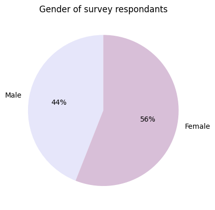

```python
num_male = df[df['Gender'] == 'Male'].shape[0]
num_female = df[df['Gender'] == 'Female'].shape[0]
plt.pie(
    [num_male, num_female],
    labels=['Male', 'Female'],
    startangle=90,
    autopct='%1.f%%',
    colors=['lavender', 'thistle'])
plt.title('Gender of survey respondants')
plt.show()
```

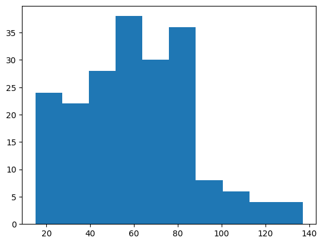

```python
plt.hist(df['Annual Income (k$)'], bins=10)
plt.show()
```

Our distribution appears slightly skewed to the right. Not as many people are making over $100k per year.

Let's take a look at people's annual income vs. spending score:

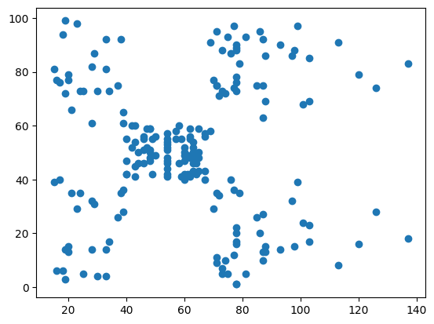

```python
X = df[['Annual Income (k$)', 'Spending Score (1-100)']]
plt.scatter(X['Annual Income (k$)'], X['Spending Score (1-100)'])
plt.show()
```

This looks promising, we can see our customers seem to fall into ~5 categories:

### Clustering the data using K Means

Let's start clustering our data!

To do so, we simply load the `sklearn.cluster.KMeans` object - with our desired number of clusters `k = 5`:

```python
km = KMeans(n_clusters=5, random_state=42)
km.fit(X)
```

```
KMeans(n_clusters=5, random_state=42)
```

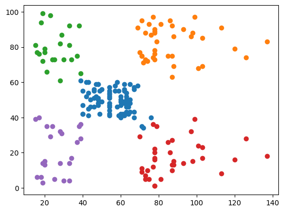

```python
for label in np.unique(km.labels_):
    X_ = X[label == km.labels_]
    plt.scatter(X_['Annual Income (k$)'], X_['Spending Score (1-100)'], label=label)
plt.show()
```

Awesome! Our KMeans algorithm was able to correctly group our data into the 5 categories that we initially noticed

## Example 3: Image Segmentation

Image segmentation is the process of locating objects and boundaries in an image.

Various clustering can be used for this task.

**How** is this done?:

1. We cluster pixels using their brightness (grayscale) or RGB values (color).
2. We replace each pixel with the average brightness or RGB value of pixels in their cluster.

Let's look at an example using KMeans:

### Loading the data

Let's start by loading the data into a `numpy.array` and taking a look at the image:

[figure not shown]

```
The image is 487px by 490px
```

```python
import numpy as np
from PIL import Image
import requests
from io import BytesIO
import matplotlib.pyplot as plt

url = 'https://cf-courses-data.s3.us.cloud-object-storage.appdomain.cloud/IBM-ML0187EN-SkillsNetwork/labs/module%203/images/cameraman.png'

# Fetch the image from the URL
response = requests.get(url)
img = Image.open(BytesIO(response.content))

# Convert the image to a NumPy array
img_array = np.array(img)

# Display the image
plt.imshow(img_array)
plt.axis('off')
plt.show()

# Print the dimensions of the image
img_dimensions = img.size
print(f'The image is {img_dimensions[0]}px by {img_dimensions[1]}px')
```

### Segmenting the image using 2 clusters

In this example, we will segment our image into `k = 2` color-clusters:

```python
k = 2

X = img_array.reshape(-1, 1)
km = KMeans(n_clusters=k, random_state=42)
```

```python
km.fit(X)
```

```
KMeans(n_clusters=2, random_state=42)
```

Let's see our segmented image; once we replace each pixel with the mean of the cluster it belongs to:

[figure not shown]

```python
seg = np.zeros(X.shape)
for i in range(k):
    seg[km.labels_ == i] = km.cluster_centers_[i]
seg = seg.reshape(img_array.shape)
plt.imshow(seg)
```